# Generation of Virtual Populations in R with mrgsolve

University at Buffalo CDSE Days 2019

Kyle Baron & Timothy Knab / MetrumRG

# Introduction

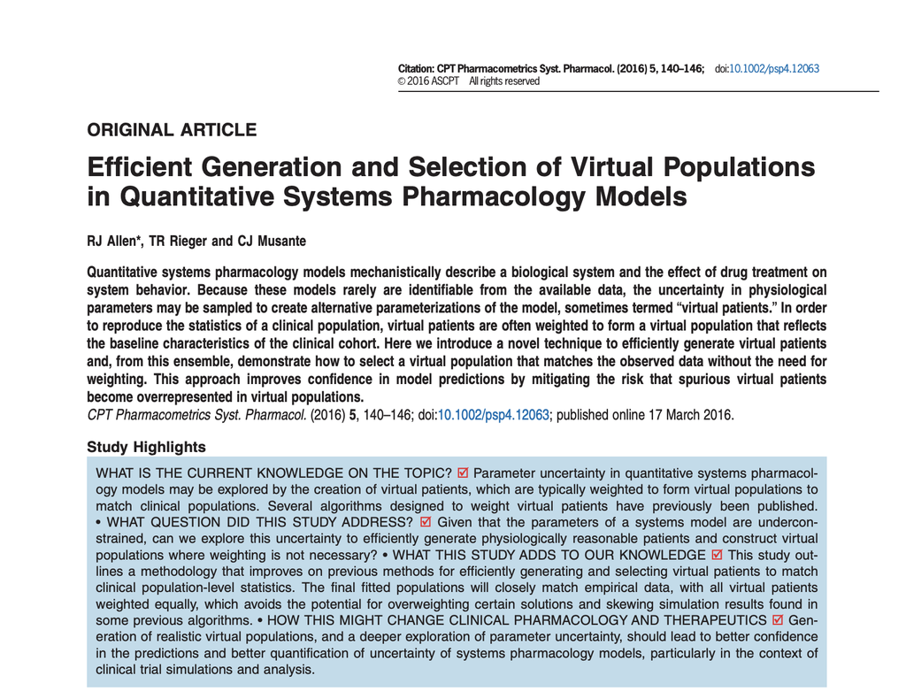

Allen, R.J., Rieger, T.R., & Musante, C.J. (2016). Efficient Generation and Selection of Virtual Populations in Quantitative Systems Pharmacology Models. CPT: pharmacometrics & systems pharmacology, 5 3, 140-6.

# Definitions

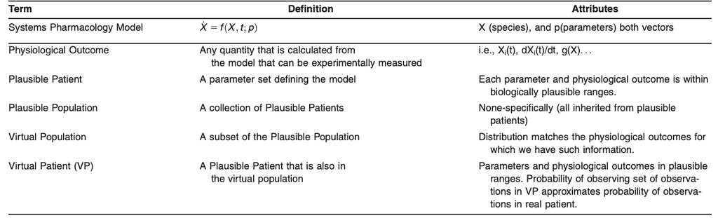

Definitions of plausible and virtual patients and populations

# Workflow

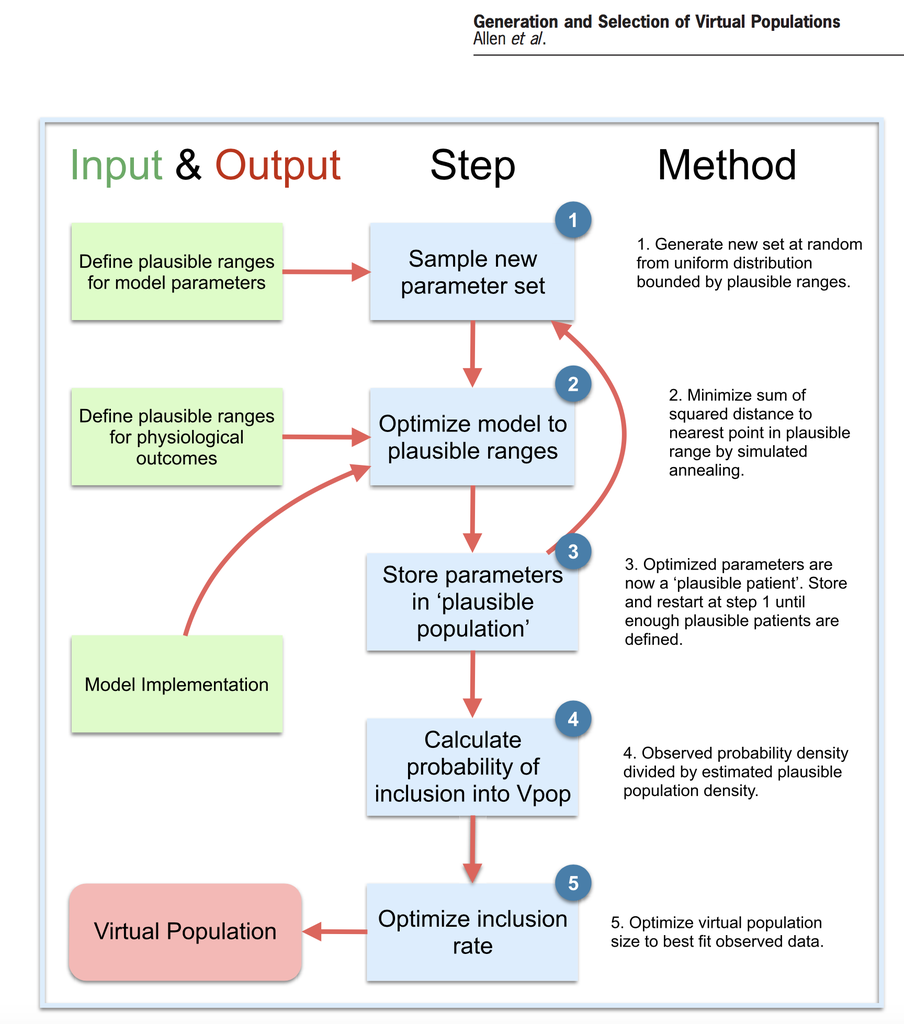

# Overview of MAPK Virtual Population

- Try to re-create oberved (simulated) distribution of tumor sizes for GDC treatment
  - start with mapk model
  - only data is tumor size at 56 days

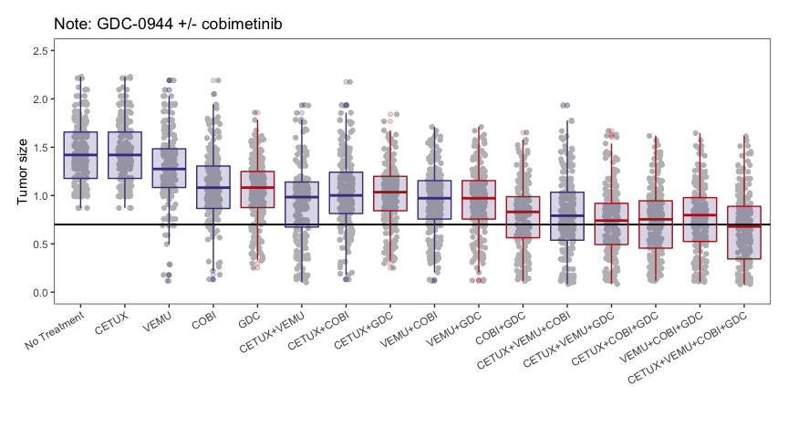

# Plausible Patients

- Parameters which are to be varied in the model are identified and physiologic limits on the bounds of these parameters are established based:
  - intiution
  - data
  - experience
- In the mapk model the following 27 parameters are considered:

```
##  [1] "BRAFt" "CRAFt" "dmax"  "G13"   "Gspry" "Gdusp" "ke2"   "ke3"
##  [9] "ke4"   "MEKb"  "MEKt"  "PI3Kb" "PI3Kt" "RASb"  "RASt"  "RTK1t"
## [17] "RTK2t" "wOR"   "wRAS"  "ka2"   "V2"    "ka3"   "q2"    "V3"
## [25] "V3b"   "ka4"   "V4"
```

# Plausible Patients

- Parameter limits set at 50% smaller than the minimum and 50% greater than the maximum values from the reported virtual population
  - Often have to do this based on physiology, prior knowledge
- Initially, no limits on upper bound of tumor size, lower limit = 0.
  - Can set limits at multiple time point (i.e constrained trajectories)

# Plausible Patients

```r
params <- readRDS("../mapk/s10vpop_pk.RDS")
pLower <- params %>% summarise_all(.funs = function(x){min(x)*0.5})
pUpper <- params %>% summarise_all(.funs = function(x){max(x)*1.5})
pLower %<>% gather(key="Name",value="Lower")
pUpper %<>% gather(key="Name",value="Upper")
paramLims <- left_join(pLower,pUpper,by="Name")
paramLims %<>% filter(Name %in% p_names)
kable(paramLims)
```

| Name | Lower | Upper |
| --- | --- | --- |
| BRAFt | 0.4500000 | 1.422970e+01 |
| CRAFt | 0.4255413 | 1.869358e+00 |
| dmax | 0.0165304 | 7.826700e-02 |
| G13 | 0.0232258 | 1.500000e+00 |
| Gspry | 0.0272101 | 1.500000e+00 |
| Gdusp | 0.0162001 | 1.500000e+00 |
| ke2 | 0.0261162 | 1.918298e+00 |
| ke3 | 0.1690308 | 2.373814e+00 |
| ke4 | 0.1149115 | 6.152933e+00 |
| MEKb | 0.0000010 | 3.874368e+00 |
| MEKt | 0.0394415 | 2.694055e+01 |
| PI3Kb | 0.0003593 | 7.735705e+00 |
| PI3Kt | 0.5000000 | 7.735705e+00 |
| RASb | 0.0034015 | 6.129698e-01 |
| RASt | 0.0442520 | 2.633074e+01 |
| RTK1t | 0.0004352 | 8.721113e+01 |
| RTK2t | 0.0001469 | 5.502290e+01 |
| wOR | 0.3769756 | 1.500000e+00 |
| wRAS | 0.3278130 | 1.500000e+00 |
| ka2 | 0.1942810 | 1.310347e+02 |
| V2 | 12.4518572 | 7.203180e+02 |
| ka3 | 0.4273688 | 1.223939e+03 |
| q2 | 25.8518425 | 3.643031e+03 |
| V3 | 50.1279601 | 2.356503e+03 |
| V3b | 25.4701092 | 4.326330e+03 |
| ka4 | 0.1635798 | 1.266548e+05 |
| V4 | 33.8116991 | 7.922191e+02 |

# Plausible Patients

```r
stateLims <- data.frame(Name = 'TUMOR','Lower'=0,'Upper'=Inf,Time=56)
kable(stateLims)
```

| Name | Lower | Upper | Time |
| --- | --- | --- | --- |
| TUMOR | 0 | Inf | 56 |

# Plausible Patient Generation

A set of initial random parameters is used as the initial guess for a simulated annealing (SA) optimization algorithm

- Typically:
  $$f(p) = \sum_{i=1...m}(M_i(p) - d_i)^2$$
- Want to converge to plausible region, $L$, as defined by the output constraints:
  $$L = X_1 \times ... \times X_m$$

  where $X_i=[l_i,u_i]$ are the lower and upper bounds, respectively for ouput $i$.
- new objective function, $g(p)$, flat-bottomed quadratic:
  $$g(p) = \sum_{i=1...m}max((M_i(p) - c_i)^2-(u_i-c_i)^2,0)$$

  where $c_i=\frac{l_i+u_i}{2}$. The result of this is $g(p) = 0$ if $M(p) \in L$.
- SA algorithm stops when OFV = 0 (or some threshold)
  - parameter set that meets all parameter and state constraints has been found
  - repeated many times with different initial parameter guesses
    - stochastic nature of SA algorithm leads to unique and independent plausible patient population

# Simulation Function

```r
model <- mread("mapk", '../mapk/', soloc = '../mapk')
sim_fcn <- function(parameters=NULL,model,pnames,dosing,ICs,simulate=0){
  loadso(model) # Load model
  # Case with parameters defined by plausible patient algorithm
  if(!is.null(parameters)){
    param_in <- data.frame(Names = pnames,Values=parameters)
    param_in <- spread(param_in,key=Names,value=Values)
  # Create case for testing with default parameters
  }else{
    param_in <- data.frame(ID=1)
  }
  # Bind parameters with initial conditions
  param_in %<>% cbind(ICs)
  # Simulate and extract tumor size at dat 56
  output <- model%>%idata_set(param_in) %>%Req(TUMOR)%>%
    obsonly%>%mrgsim(delta=56,end=56,events=as.ev(dosing))%>%
    filter(time==56)%>%as.data.frame()
  # For VP generation, return a list of steady state and non-steady state outputs
  if(simulate==0){
    return(list(NSS=output))
  # Otherwise return the dataset
  }else{
    return(output)
  }
}
```

# Generate Plausible Patients

```r
control=list(runParallel="parallel",nCores = 4,
                       parallel_libs="mrgsolve") # Setup parallel run
plausiblePatients <- generatePPs(model_fn = sim_fcn, NP=1e3, paramLims=paramLims,stateLims = stateLims,
                                 method='SA',
                                 model_args = model_args,
                                 scoreThreshold = 0)
```

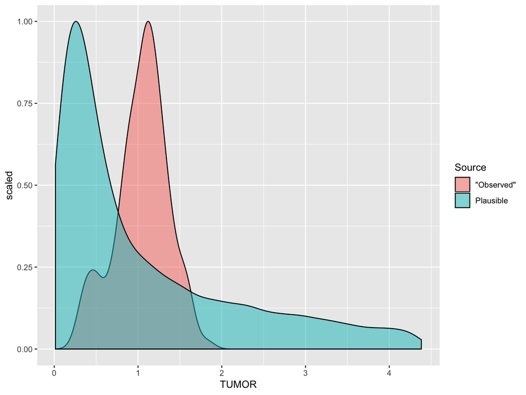

# Virtual Population

- Unlikely that plausible population distribution(s) will match data
  - need to decide which plausible patients to include in virtual population -> resampling
- Consider the selection function $S:V_{pl} \rightarrow \{0,1\}$ as:
  $$S(p_j) = \begin{cases}
  1, \text{ if } p_j \in V_{pop}\\
  0, \text{ if otherwise}
  \end{cases}$$
- From Bayes’ thereom we have:
  $$P\left(S(p_j) = 1 | M(p_j)\in R\right) = \frac{\left(M(p_j)\in R|S(p_j) = 1\right)P\left( S(p_j)=1\right)}{P\left( M(p_j)\in R\right)}$$

  this gives the probability of a plausible patient $p_j$, given that $M(p_j)$ (the simulated outcomes) is in the region $R$ and is also a **virtual patient**.
- If $p_j$ is in the virtual population then the probability of $M(p_j)$ being in the same region $R$ should be approximately equal to the probability of observing the clinical or empirical data in the region $R$.
  - if $d \in D$, Bayes’ rule from above can be re-written as:
    $$P\left(S(p_j) = 1|M(p_j)\in R\right) \approx \frac{P(d\in R)P\left(S(p_j)=1\right)}{P\left(M(p_j)\in R\right)}$$

# Virtual Population

$P\left(S(p_j)=1\right)$ is unknown

- For a fixed plausible population $P\left(S(p_j)=1\right)$ should be a constant
- Reformulate Bayes’ Rule again:
  $$P\left(S(p_j)=1|M(p_j)\in R\right) \approx \alpha\frac{P(d\in R)}{P\left(M(p_j)\in R\right)}$$
- Need to compute $P(d\in R)$ and $P\left(M(p_j) \in R\right)$
  - Use kernel density estimate (KDE)
    - univariate for mapk problem, can be multivariate (warning: computationally expensive)
- $\alpha$ ~ size of the virtual population (or the inclusion rate into the virtual population)
  - Here $\alpha$ will be optimized using particle swarm optimization (PSO) for speed and robustness
  - a vector of random numbers $r_1,r_2...r_i...r_N$ is generated from the uniform distribution and if $r_i < \alpha\frac{P(d\in R)}{P\left(M(p_j)\in R\right)}$ $p_i$ is selected as a possible member of the virtual population
  - “Score” or OFV: two-sample Kolmogorov-Smirnov Test statistics between $p_{select}$ and the empirical distribution for each measured outcome in the data (not strictly applicable for multivariate problems)
  - find $\alpha$ to minimize OFV
- **Note:** for robustness, rejection-sampling is repeated between 10 and 50 times for each value of $\alpha$ and the final objective function value is taken as the average of the summed KS scores over all trials.
- Final VP generated by resampling with optimal $\alpha$

# Virtual Population (Results)

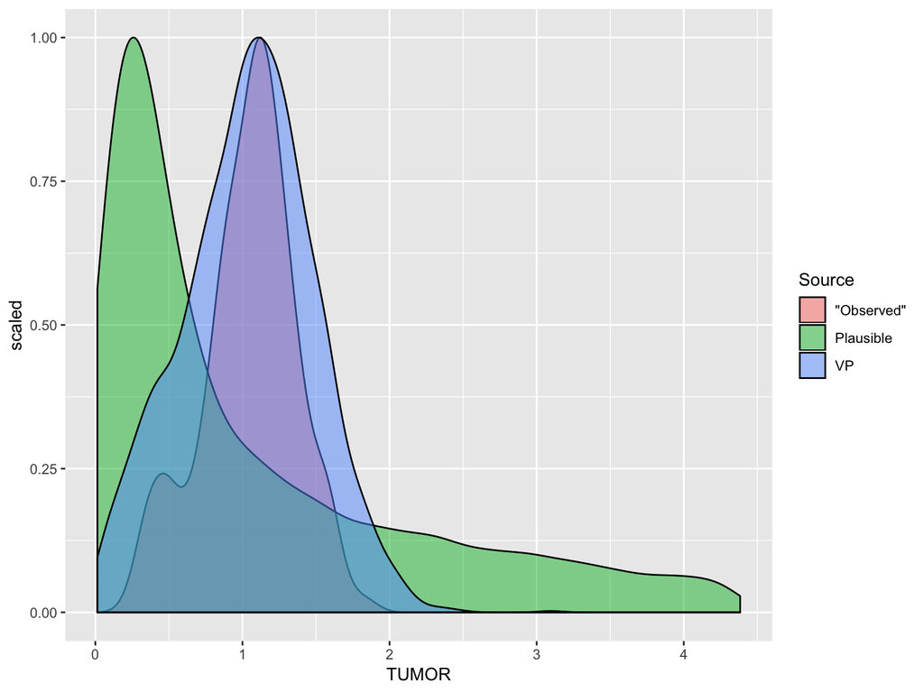

# Virtual Population Efficiency

Yield: $N_{VP}/N_{PP}$ = 21.8%

- How can we increase VPop efficiency? * More closely approximate final distribution with plausible patients -> better bounds

```r
stateLims <- data.frame(Name = 'TUMOR','Lower'=0,'Upper'=2.5,Time=56)
kable(stateLims)
```

| Name | Lower | Upper | Time |
| --- | --- | --- | --- |
| TUMOR | 0 | 2.5 | 56 |

# Virtual Population Efficiency

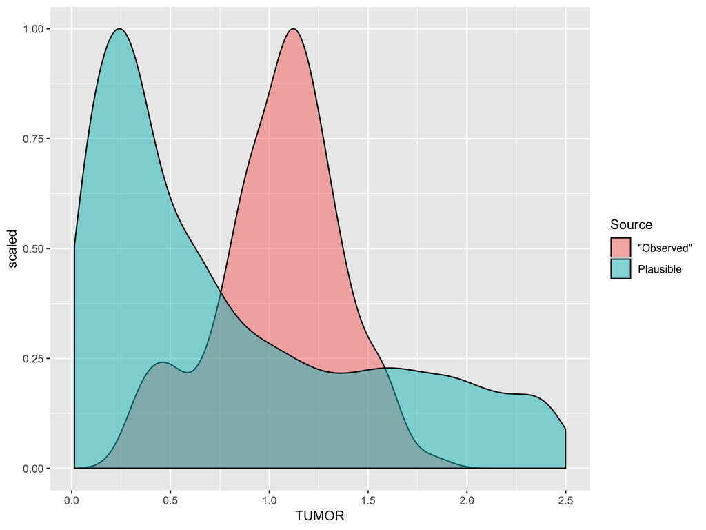

# Virtual Population Effiency

Yield = 25.5%

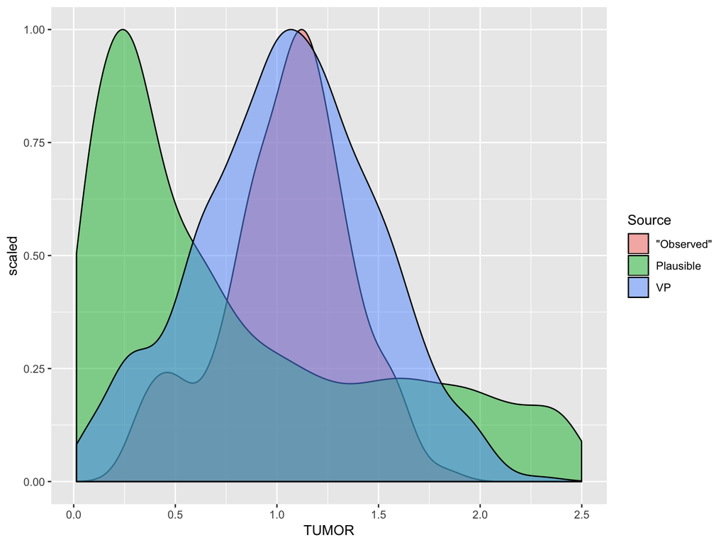

# Further Improvements

See *Rieger TR, Allen RJ, Bystricky L, Chen Y, Colopy GW, Cui Y, Gonzalez A, Liu Y, White RD, Everett RA, Banks HT, Musante CJ: Improving the generation and selection of virtual populations in quantitative systems pharmacology models. Prog Biophys Mol Biol 139:15–22, 2018*

- Alternative optimization algorithms for plausible patient generation
  - nested simulated annealing: augments the SA method by targeting PP generation using the probability density function of the target distribution
  - genetic algorithm: iteratively builds a plausible population according to a fitness function defined by the desired distribution
  - Metropolis-Hastings: importance samping

# Further Improvements and Performance

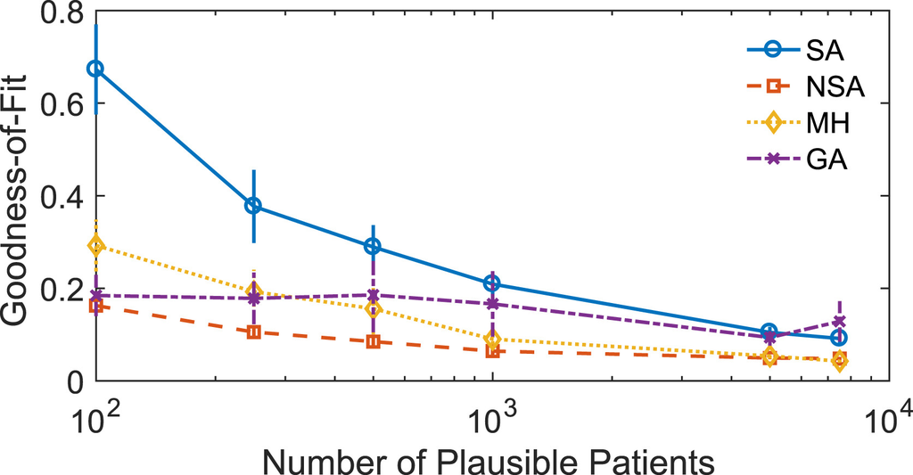

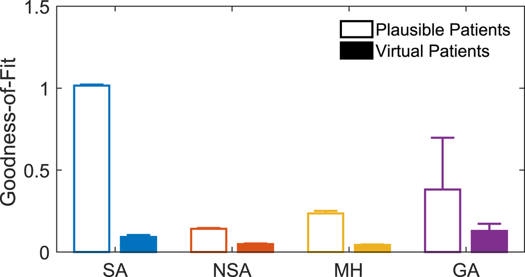

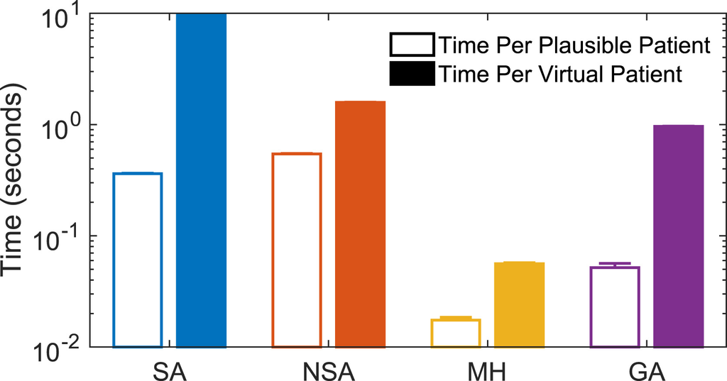